# StarHotelSolution

```python
# this will help in making the Python code more structured automatically (good coding practice)
%load_ext nb_black

# Library to suppress warnings or deprecation notes
import warnings

warnings.filterwarnings("ignore")

# Libraries to help with reading and manipulating data

import pandas as pd
import numpy as np

# Library to split data
from sklearn.model_selection import train_test_split

# libaries to help with data visualization
import matplotlib.pyplot as plt
import seaborn as sns

# Removes the limit for the number of displayed columns
pd.set_option("display.max_columns", None)
# Sets the limit for the number of displayed rows
pd.set_option("display.max_rows", 200)

# Libraries to build decision tree classifier
from sklearn.tree import DecisionTreeClassifier
from sklearn import tree

# To tune different models
from sklearn.model_selection import GridSearchCV

# To perform statistical analysis
import scipy.stats as stats

# To get diferent metric scores
from sklearn.metrics import (
    f1_score,
    accuracy_score,
    recall_score,
    precision_score,
    confusion_matrix,
    plot_confusion_matrix,
    make_scorer,
)

# To build model for prediction
import statsmodels.stats.api as sms
from statsmodels.stats.outliers_influence import variance_inflation_factor
import statsmodels.api as sm
from statsmodels.tools.tools import add_constant
from sklearn.linear_model import LogisticRegression


# To get diferent metric scores
from sklearn.metrics import (
    f1_score,
    accuracy_score,
    recall_score,
    precision_score,
    confusion_matrix,
    roc_auc_score,
    plot_confusion_matrix,
    precision_recall_curve,
    roc_curve,
)
```

```
The nb_black extension is already loaded. To reload it, use:
  %reload_ext nb_black
```

### Load the data

```python
# read the data into a dataframe
starhotel = pd.read_csv("StarHotelsGroup.csv")
```

```python
# make a copy of the dataframe
data = starhotel.copy()
```

### View the first 5 rows of the dataset

```python
data.head()
```

|  | no_of_adults | no_of_children | no_of_weekend_nights | no_of_week_nights | type_of_meal_plan | required_car_parking_space | room_type_reserved | lead_time | arrival_year | arrival_month | arrival_date | market_segment_type | repeated_guest | no_of_previous_cancellations | no_of_previous_bookings_not_canceled | avg_price_per_room | no_of_special_requests | booking_status |
| --- | --- | --- | --- | --- | --- | --- | --- | --- | --- | --- | --- | --- | --- | --- | --- | --- | --- | --- |
| 0 | 2 | 0 | 1 | 2 | Meal Plan 1 | 0 | Room_Type 1 | 224 | 2017 | 10 | 2 | Offline | 0 | 0 | 0 | 65.00 | 0 | Not_Canceled |
| 1 | 2 | 0 | 2 | 3 | Not Selected | 0 | Room_Type 1 | 5 | 2018 | 11 | 6 | Online | 0 | 0 | 0 | 106.68 | 1 | Not_Canceled |
| 2 | 1 | 0 | 2 | 1 | Meal Plan 1 | 0 | Room_Type 1 | 1 | 2018 | 2 | 28 | Online | 0 | 0 | 0 | 60.00 | 0 | Canceled |
| 3 | 2 | 0 | 0 | 2 | Meal Plan 1 | 0 | Room_Type 1 | 211 | 2018 | 5 | 20 | Online | 0 | 0 | 0 | 100.00 | 0 | Canceled |
| 4 | 3 | 0 | 0 | 3 | Not Selected | 0 | Room_Type 1 | 277 | 2019 | 7 | 13 | Online | 0 | 0 | 0 | 89.10 | 2 | Canceled |

### Understand the shape of the dataset.

```python
data.shape
```

```
(56926, 18)
```

- The dataset has 56926 rows and 18 columns

### Check the data types of the columns for the dataset

```python
data.info()
```

```
<class 'pandas.core.frame.DataFrame'>
RangeIndex: 56926 entries, 0 to 56925
Data columns (total 18 columns):
 #   Column                                Non-Null Count  Dtype
---  ------                                --------------  -----
 0   no_of_adults                          56926 non-null  int64
 1   no_of_children                        56926 non-null  int64
 2   no_of_weekend_nights                  56926 non-null  int64
 3   no_of_week_nights                     56926 non-null  int64
 4   type_of_meal_plan                     56926 non-null  object
 5   required_car_parking_space            56926 non-null  int64
 6   room_type_reserved                    56926 non-null  object
 7   lead_time                             56926 non-null  int64
 8   arrival_year                          56926 non-null  int64
 9   arrival_month                         56926 non-null  int64
 10  arrival_date                          56926 non-null  int64
 11  market_segment_type                   56926 non-null  object
 12  repeated_guest                        56926 non-null  int64
 13  no_of_previous_cancellations          56926 non-null  int64
 14  no_of_previous_bookings_not_canceled  56926 non-null  int64
 15  avg_price_per_room                    56926 non-null  float64
 16  no_of_special_requests                56926 non-null  int64
 17  booking_status                        56926 non-null  object
dtypes: float64(1), int64(13), object(4)
memory usage: 7.8+ MB
```

- Dependent variable is categorical
- Columns are consistent
- There are no missing values in the dataset
- Most of the columns are integers,average price is float.Categorical independent variables are type_of_meal_plan,room_type_reserved,market_segment_type and booking_status

### Summary of the dataset

```python
data.describe().T
```

|  | count | mean | std | min | 25% | 50% | 75% | max |
| --- | --- | --- | --- | --- | --- | --- | --- | --- |
| no_of_adults | 56926.0 | 1.875856 | 0.518667 | 0.0 | 2.0 | 2.0 | 2.0 | 4.0 |
| no_of_children | 56926.0 | 0.110723 | 0.408885 | 0.0 | 0.0 | 0.0 | 0.0 | 10.0 |
| no_of_weekend_nights | 56926.0 | 0.835840 | 0.875900 | 0.0 | 0.0 | 1.0 | 2.0 | 8.0 |
| no_of_week_nights | 56926.0 | 2.261901 | 1.432371 | 0.0 | 1.0 | 2.0 | 3.0 | 17.0 |
| required_car_parking_space | 56926.0 | 0.026332 | 0.160123 | 0.0 | 0.0 | 0.0 | 0.0 | 1.0 |
| lead_time | 56926.0 | 93.713909 | 92.408296 | 0.0 | 21.0 | 65.0 | 142.0 | 521.0 |
| arrival_year | 56926.0 | 2018.248340 | 0.644619 | 2017.0 | 2018.0 | 2018.0 | 2019.0 | 2019.0 |
| arrival_month | 56926.0 | 6.490215 | 3.027185 | 1.0 | 4.0 | 6.0 | 9.0 | 12.0 |
| arrival_date | 56926.0 | 15.635913 | 8.718717 | 1.0 | 8.0 | 16.0 | 23.0 | 31.0 |
| repeated_guest | 56926.0 | 0.024664 | 0.155099 | 0.0 | 0.0 | 0.0 | 0.0 | 1.0 |
| no_of_previous_cancellations | 56926.0 | 0.020939 | 0.326142 | 0.0 | 0.0 | 0.0 | 0.0 | 13.0 |
| no_of_previous_bookings_not_canceled | 56926.0 | 0.167902 | 1.943647 | 0.0 | 0.0 | 0.0 | 0.0 | 72.0 |
| avg_price_per_room | 56926.0 | 109.610570 | 38.256075 | 0.0 | 85.0 | 105.0 | 129.7 | 540.0 |
| no_of_special_requests | 56926.0 | 0.666040 | 0.814257 | 0.0 | 0.0 | 0.0 | 1.0 | 5.0 |

### Lets us look at different values in categorical variables

```python
# filtering object type columns
cat_columns = data.describe(include=["object"]).columns
cat_columns
```

```
Index(['type_of_meal_plan', 'room_type_reserved', 'market_segment_type',
       'booking_status'],
      dtype='object')
```

```python
for i in cat_columns:
    print("Unique values in", i, "are :")
    print(data[i].value_counts())
```

```
Unique values in type_of_meal_plan are :
Meal Plan 1     42330
Not Selected    10072
Meal Plan 2      4516
Meal Plan 3         8
Name: type_of_meal_plan, dtype: int64
Unique values in room_type_reserved are :
Room_Type 1    42807
Room_Type 4    10413
Room_Type 6     1581
Room_Type 5      983
Room_Type 2      823
Room_Type 7      312
Room_Type 3        7
Name: room_type_reserved, dtype: int64
Unique values in market_segment_type are :
Online           39490
Offline          13875
Corporate         2796
Complementary      536
Aviation           229
Name: market_segment_type, dtype: int64
Unique values in booking_status are :
Not_Canceled    35378
Canceled        21548
Name: booking_status, dtype: int64
```

- There are 3 meal types along with a not selected category
- There are 7 room types
- The market segment is divided into 5 categories - Online,Offline,Corporate,Complementary and Aviation
- the unique values in booking status are Not_Canceled and Canceled. This is the dependent variable

### Univariate Analysis

```python
def histogram_boxplot(data, feature, figsize=(12, 7), kde=False, bins=None):
    """
    Boxplot and histogram combined

    data: dataframe
    feature: dataframe column
    figsize: size of figure (default (12,7))
    kde: whether to show the density curve (default False)
    bins: number of bins for histogram (default None)
    """
    f2, (ax_box2, ax_hist2) = plt.subplots(
        nrows=2,  # Number of rows of the subplot grid= 2
        sharex=True,  # x-axis will be shared among all subplots
        gridspec_kw={"height_ratios": (0.25, 0.75)},
        figsize=figsize,
    )  # creating the 2 subplots
    sns.boxplot(
        data=data, x=feature, ax=ax_box2, showmeans=True, color="violet"
    )  # boxplot will be created and a star will indicate the mean value of the column
    sns.histplot(
        data=data, x=feature, kde=kde, ax=ax_hist2, bins=bins, palette="winter"
    ) if bins else sns.histplot(
        data=data, x=feature, kde=kde, ax=ax_hist2
    )  # For histogram
    ax_hist2.axvline(
        data[feature].mean(), color="green", linestyle="--"
    )  # Add mean to the histogram
    ax_hist2.axvline(
        data[feature].median(), color="black", linestyle="-"
    )  # Add median to the histogram
```

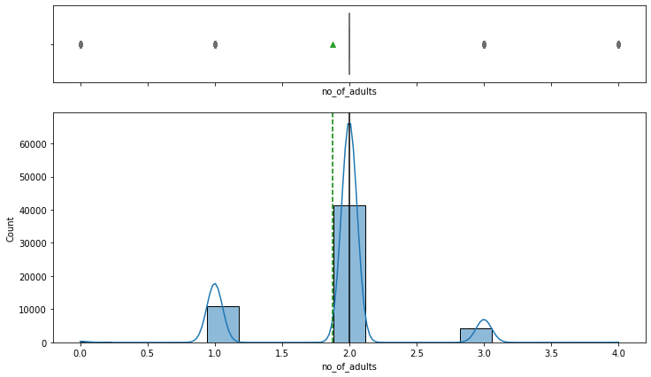

```python
histogram_boxplot(data, "no_of_adults", kde=True)
```

- The median number of adults is 2
- There are outliers on the both sides
- We will not treat these outliers as they represent the real trend

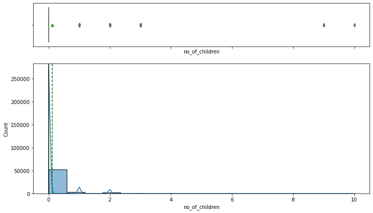

```python
histogram_boxplot(data, "no_of_children", kde=True)
```

```python
# Create subframe to check how many rows of data has number of children greater than 10
data1 = data[(data["no_of_children"] == 10)]
data1.shape
```

```
(1, 18)
```

- The median number of children accompanied by the guest is zero or none
- It is right skewed
- There are outliers at the right end
- We will treat this outliers of 10 children as it seems to be invalid or inconsistent data. We will impute the median value in this row so that this outlier can be treated

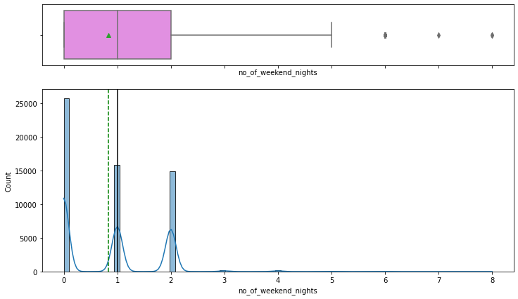

```python
histogram_boxplot(data, "no_of_weekend_nights", kde=True)
```

- This variable is skewed on both the sides
- There are outliers towards the right end
- We will not treat these outliers as they represent a different booking trend

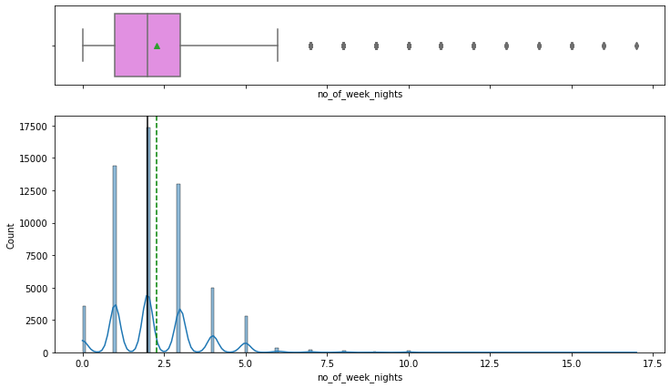

```python
histogram_boxplot(data, "no_of_week_nights", kde=True)
```

```python
# function to create labeled barplots


def labeled_barplot(data, feature, perc=False, n=None):
    """
    Barplot with percentage at the top

    data: dataframe
    feature: dataframe column
    perc: whether to display percentages instead of count (default is False)
    n: displays the top n category levels (default is None, i.e., display all levels)
    """

    total = len(data[feature])  # length of the column
    count = data[feature].nunique()
    if n is None:
        plt.figure(figsize=(count + 1, 5))
    else:
        plt.figure(figsize=(n + 1, 5))

    plt.xticks(rotation=90, fontsize=15)
    ax = sns.countplot(
        data=data,
        x=feature,
        palette="Paired",
        order=data[feature].value_counts().index[:n].sort_values(),
    )

    for p in ax.patches:
        if perc == True:
            label = "{:.1f}%".format(
                100 * p.get_height() / total
            )  # percentage of each class of the category
        else:
            label = p.get_height()  # count of each level of the category

        x = p.get_x() + p.get_width() / 2  # width of the plot
        y = p.get_height()  # height of the plot

        ax.annotate(
            label,
            (x, y),
            ha="center",
            va="center",
            size=12,
            xytext=(0, 5),
            textcoords="offset points",
        )  # annotate the percentage

    plt.show()  # show the plot
```

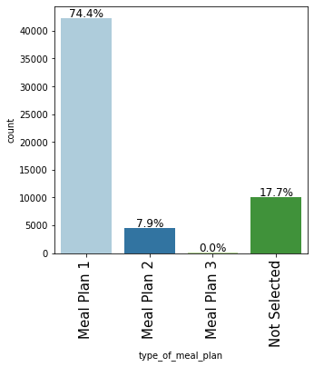

```python
labeled_barplot(data, "type_of_meal_plan", perc=True)
```

- Hotel guests are preferring Meal Plan 1 over the other meal types
- 17.7 % of guests are not selecting any meal plan. It is percentage of population that the can be targeted for understanding other meal preferences and including them in the hotel meal offerings

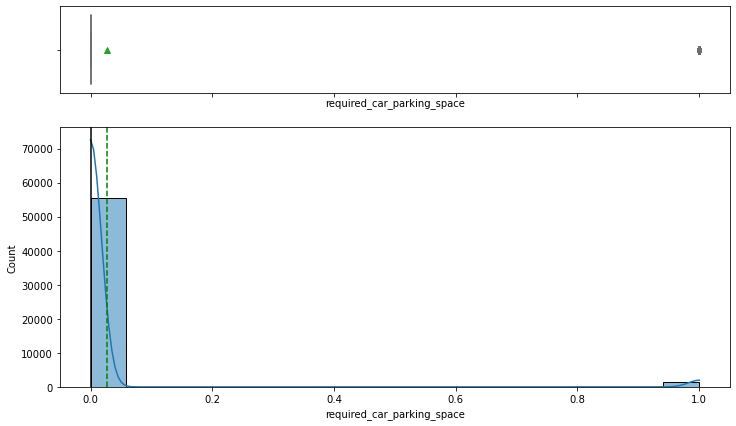

```python
histogram_boxplot(data, "required_car_parking_space", kde=True)
```

- Median required car parking space is zero
- The distribution is right skewed
- There are outliers towards the right
- We will not treat these outliers as they are not invalid data

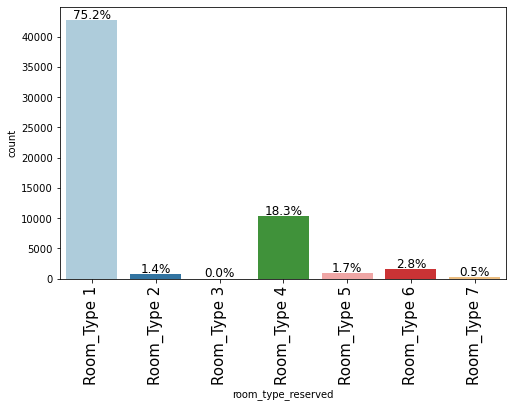

```python
labeled_barplot(data, "room_type_reserved", perc=True)
```

- Room type 1 is the most popular followed by room type 4 and room type 6

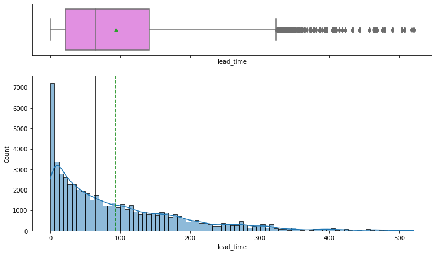

```python
histogram_boxplot(data, "lead_time", kde=True)
```

```python
data["lead_time"].mean()
```

```
93.71390928573938
```

- This variable is right skewed
- The median lead time is 65 days
- Values over 93 days(which is the mean of this variable) seem unrealistic.These outliers will be treated.

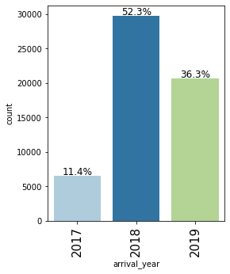

```python
labeled_barplot(data, "arrival_year", perc=True)
```

- Hotel has been booked the highest in 2018 followed by 2019 and 2017

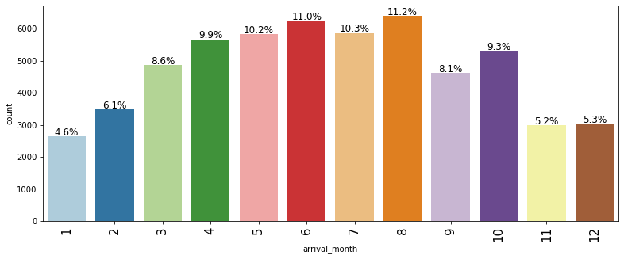

```python
labeled_barplot(data, "arrival_month", perc=True)
```

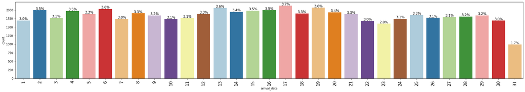

```python
labeled_barplot(data, "arrival_date", perc=True)
```

- Maximum number of bookings are on 17th followed by 6th,13th and 19th

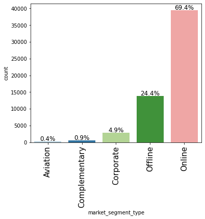

```python
labeled_barplot(data, "market_segment_type", perc=True)
```

- Online bookings are the highest followed by offline and Corporate

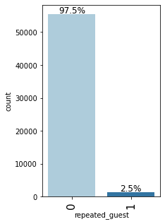

```python
labeled_barplot(data, "repeated_guest", perc=True)
```

- The percentage of repeated guests is very low of 2.5%
- Based off the barplot,it looks like most of the guests are first timers and there is no customer loyalty towards the hotel

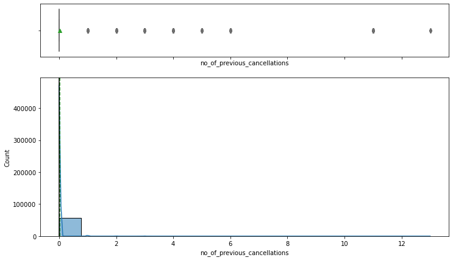

```python
histogram_boxplot(data, "no_of_previous_cancellations", kde=True)
```

- This variable is right skewed
- There are outliers to the right end
- We will not treat these outliers as they are not invalid data

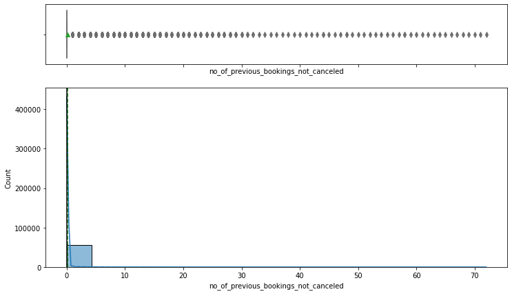

```python
histogram_boxplot(data, "no_of_previous_bookings_not_canceled", kde=True)
```

- This variable is right skewed
- There are outliers to the right end
- We will not treat these outliers as they are not invalid data

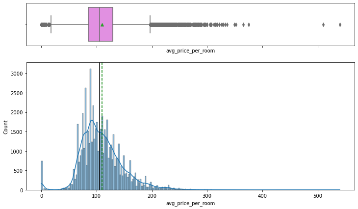

```python
histogram_boxplot(data, "avg_price_per_room", kde=True)
```

```python
# Create a subframe & check how many records are above 500 euros
data2 = data[(data["avg_price_per_room"] >= 500)]
data2.head()
```

|  | no_of_adults | no_of_children | no_of_weekend_nights | no_of_week_nights | type_of_meal_plan | required_car_parking_space | room_type_reserved | lead_time | arrival_year | arrival_month | arrival_date | market_segment_type | repeated_guest | no_of_previous_cancellations | no_of_previous_bookings_not_canceled | avg_price_per_room | no_of_special_requests | booking_status |
| --- | --- | --- | --- | --- | --- | --- | --- | --- | --- | --- | --- | --- | --- | --- | --- | --- | --- | --- |
| 5656 | 1 | 0 | 0 | 1 | Meal Plan 1 | 0 | Room_Type 1 | 0 | 2019 | 5 | 9 | Online | 0 | 0 | 0 | 510.0 | 0 | Canceled |
| 51939 | 2 | 0 | 0 | 1 | Meal Plan 1 | 0 | Room_Type 1 | 35 | 2018 | 3 | 25 | Offline | 0 | 0 | 0 | 540.0 | 0 | Canceled |

- This variable is skewed on both ends
- There are outliers on both the ends
- There 2 rows where the average price is greater than 500 euros. We will impute this row with median so that this outlier can be treated

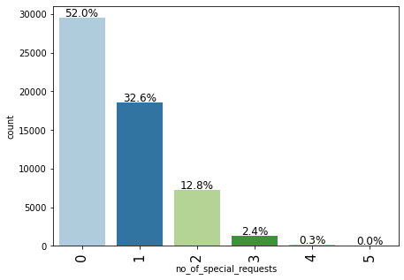

```python
labeled_barplot(data, "no_of_special_requests", perc=True)
```

- About 52% guests do not seem to be making any special requests
- There is 32.6% of guests making 1 request followed by 12.8% guests that are making 2 requests

### Bivariate analysis

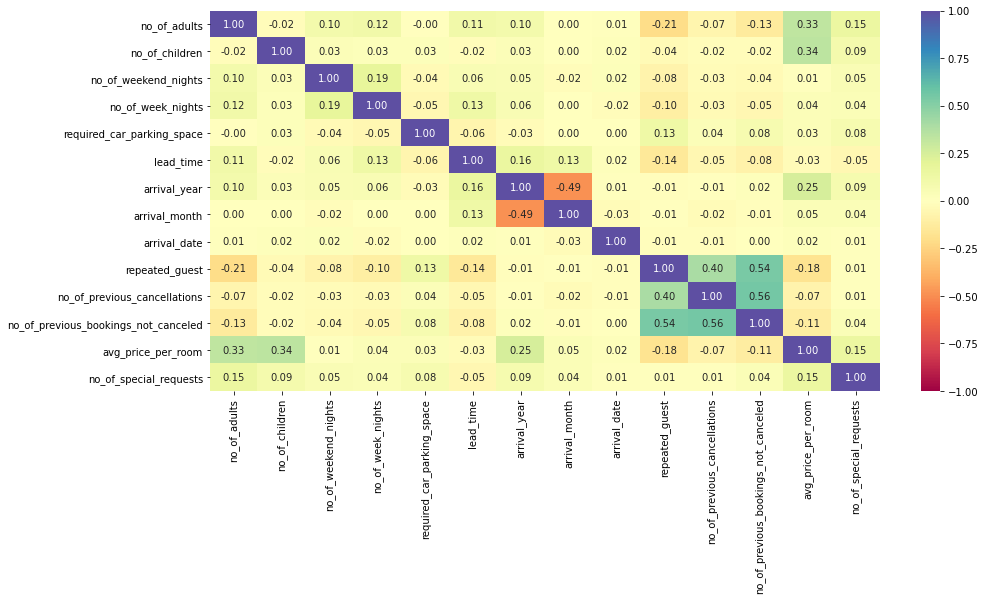

```python
plt.figure(figsize=(15, 7))
sns.heatmap(data.corr(), annot=True, vmin=-1, vmax=1, fmt=".2f", cmap="Spectral")
plt.show()
```

```python
### Function to plot stacked bar charts for categorical columns
def stacked_plot(x):
    sns.set()
    ## crosstab
    tab1 = pd.crosstab(x, data["salary"], margins=True).sort_values(
        by=" >50K", ascending=False
    )
    print(tab1)
    print("-" * 120)
    ## visualising the cross tab
    tab = pd.crosstab(x, data["salary"], normalize="index").sort_values(
        by=" >50K", ascending=False
    )
    tab.plot(kind="bar", stacked=True, figsize=(17, 7))
    plt.legend(
        loc="lower left",
        frameon=False,
    )
    plt.legend(loc="upper left", bbox_to_anchor=(1, 1))
    plt.show()
```

```python
def stacked_barplot(data, predictor, target):
    """
    Print the category counts and plot a stacked bar chart

    data: dataframe
    predictor: independent variable
    target: target variable
    """
    count = data[predictor].nunique()
    sorter = data[target].value_counts().index[-1]
    tab1 = pd.crosstab(data[predictor], data[target], margins=True).sort_values(
        by=sorter, ascending=False
    )
    print(tab1)
    print("-" * 120)
    tab = pd.crosstab(data[predictor], data[target], normalize="index").sort_values(
        by=sorter, ascending=False
    )
    tab.plot(kind="bar", stacked=True, figsize=(count + 5, 5))
    plt.legend(
        loc="lower left",
        frameon=False,
    )
    plt.legend(loc="upper left", bbox_to_anchor=(1, 1))
    plt.show()
```

```
booking_status     Canceled  Not_Canceled    All
type_of_meal_plan
All                   21548         35378  56926
Meal Plan 1           15547         26783  42330
Not Selected           3793          6279  10072
Meal Plan 2            2207          2309   4516
Meal Plan 3               1             7      8
------------------------------------------------------------------------------------------------------------------------
```

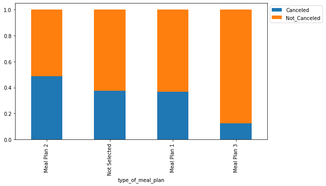

```python
stacked_barplot(data, "type_of_meal_plan", "booking_status")
```

- The cancellations is highest among guests that booked Meal Plan 2 and did not select any meal option
- It is lowest among guest that booked Meal Plan 3 and Meal Plan 1
- Hotel should investigate on Meal Plan 2 and provide offerings so that most of the guests are picking up atleast one meal option.

```
booking_status      Canceled  Not_Canceled    All
room_type_reserved
All                    21548         35378  56926
Room_Type 1            15651         27156  42807
Room_Type 4             4206          6207  10413
Room_Type 6              856           725   1581
Room_Type 5              408           575    983
Room_Type 2              311           512    823
Room_Type 7              114           198    312
Room_Type 3                2             5      7
------------------------------------------------------------------------------------------------------------------------
```

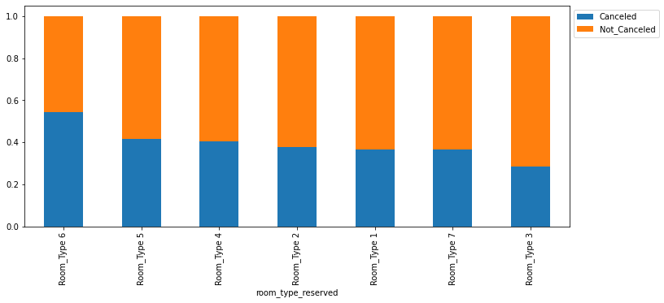

```python
stacked_barplot(data, "room_type_reserved", "booking_status")
```

- The top 3 highest number of cancellations are in Room type 1,Room type 4 and Room type 6
- Hotel needs to investigate why there are such higher number of cancellations in these room types. A brief guest survey on such room types can help identify the root cause of cancellations

```
booking_status       Canceled  Not_Canceled    All
market_segment_type
All                     21548         35378  56926
Online                  16524         22966  39490
Offline                  4538          9337  13875
Corporate                 437          2359   2796
Aviation                   49           180    229
Complementary               0           536    536
------------------------------------------------------------------------------------------------------------------------
```

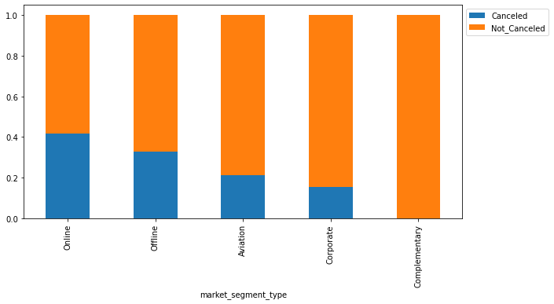

```python
stacked_barplot(data, "market_segment_type", "booking_status")
```

- The top 3 highest cancellations are from the online,offline and corporate channels
- Complementary has no cancellations followed by Aviation
- Hotel needs to investigate further on the 3 sales channel of online,offline and corporate to identify the root cause of cancellations

```python
### function to plot distributions wrt target


def distribution_plot_wrt_target(data, predictor, target):

    fig, axs = plt.subplots(2, 2, figsize=(12, 10))

    target_uniq = data[target].unique()

    axs[0, 0].set_title("Distribution of target for target=" + str(target_uniq[0]))
    sns.histplot(
        data=data[data[target] == target_uniq[0]],
        x=predictor,
        kde=True,
        ax=axs[0, 0],
        color="teal",
        stat="density",
    )

    axs[0, 1].set_title("Distribution of target for target=" + str(target_uniq[1]))
    sns.histplot(
        data=data[data[target] == target_uniq[1]],
        x=predictor,
        kde=True,
        ax=axs[0, 1],
        color="orange",
        stat="density",
    )

    axs[1, 0].set_title("Boxplot w.r.t target")
    sns.boxplot(data=data, x=target, y=predictor, ax=axs[1, 0], palette="gist_rainbow")

    axs[1, 1].set_title("Boxplot (without outliers) w.r.t target")
    sns.boxplot(
        data=data,
        x=target,
        y=predictor,
        ax=axs[1, 1],
        showfliers=False,
        palette="gist_rainbow",
    )

    plt.tight_layout()
    plt.show()
```

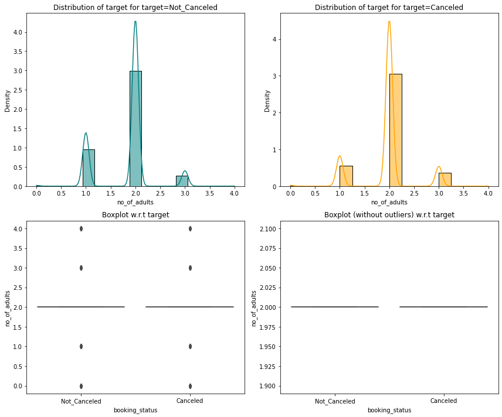

```python
distribution_plot_wrt_target(data, "no_of_adults", "booking_status")
```

- The no.of adults in the "not canceled" and the "canceled" booking status category is 2
- There are outliers in both the cases

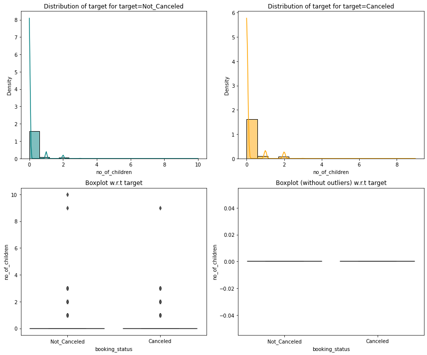

```python
distribution_plot_wrt_target(data, "no_of_children", "booking_status")
```

- The children accompanying guests are zero in the "Not canceled" and "Canceled" booking status categories
- There are outliers in both the categories

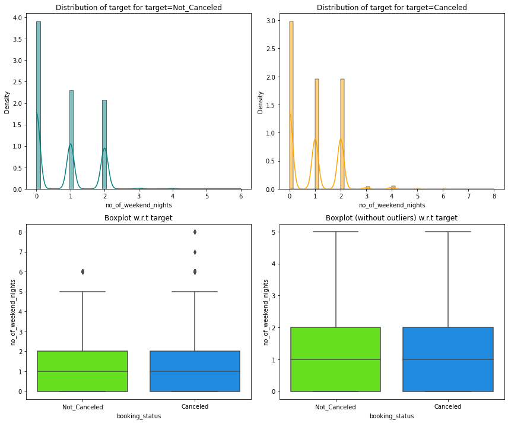

```python
distribution_plot_wrt_target(data, "no_of_weekend_nights", "booking_status")
```

- The number of weekend nights is 1 in the "Not canceled" and "Canceled" booking status categories
- There are outliers present in the both the booking status categories

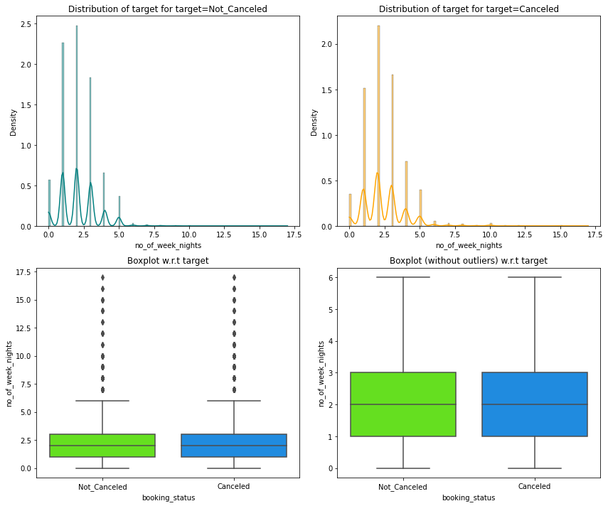

```python
distribution_plot_wrt_target(data, "no_of_week_nights", "booking_status")
```

- The number of week nights is 2 for the "Not canceled" and "Canceled" booking status categories
- There are outliers in both the categories

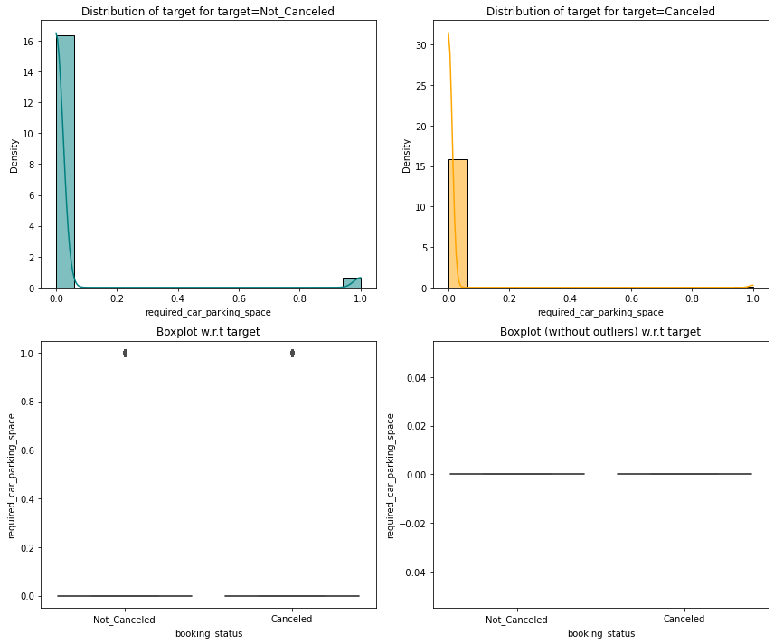

```python
distribution_plot_wrt_target(data, "required_car_parking_space", "booking_status")
```

- The required car space is zero to none for the "Not canceled" and "Canceled" booking status categories
- There is outlier in both the status categories

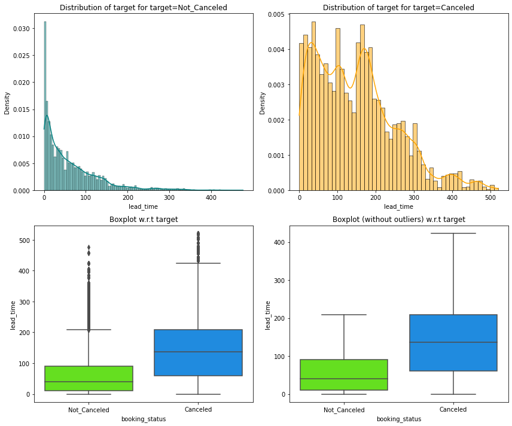

```python
distribution_plot_wrt_target(data, "lead_time", "booking_status")
```

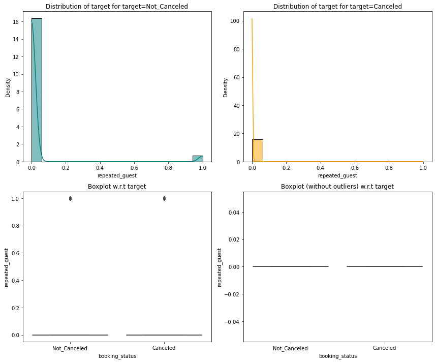

```python
distribution_plot_wrt_target(data, "repeated_guest", "booking_status")
```

- No insight on the repeated guest with "Not canceled" and "Canceled" booking status categories as both stay at zero
- There are outliers in both the categories

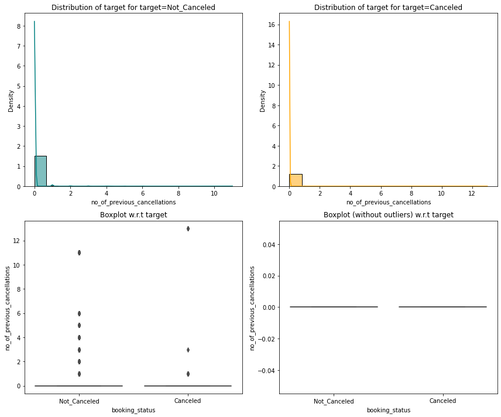

```python
distribution_plot_wrt_target(data, "no_of_previous_cancellations", "booking_status")
```

- No insight on the number of previous cancellations with "Not canceled" and "Canceled" booking status categories as both stay at zero
- There are outliers in both the categories

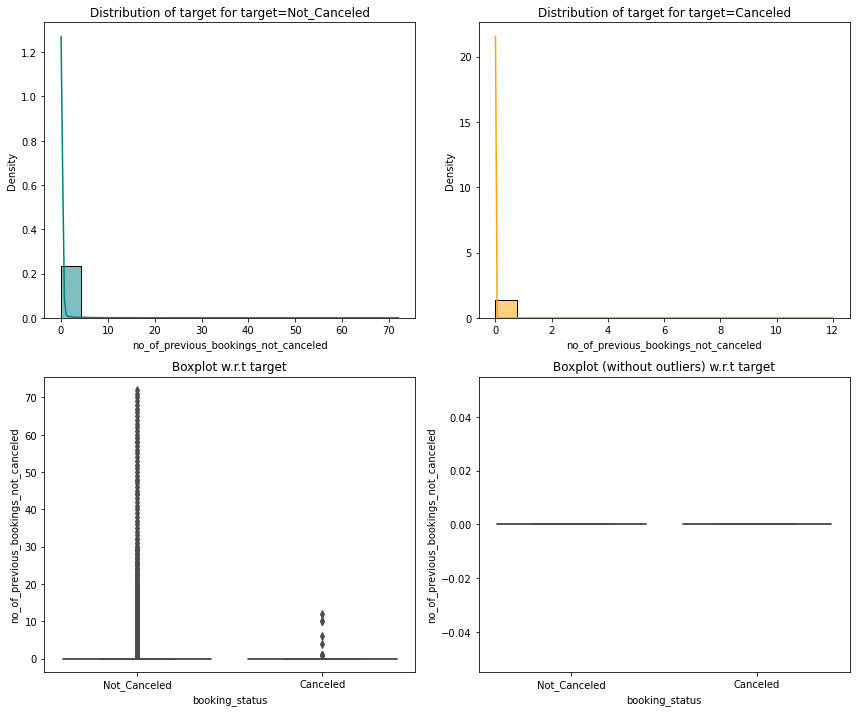

```python
distribution_plot_wrt_target(
    data, "no_of_previous_bookings_not_canceled", "booking_status"
)
```

- No insight on the number of previous non cancellations with "Not canceled" and "Canceled" booking status categories as both stay at zero
- There are outliers in both the categories